# **Problem Statement**

## Business Context

A sales forecast is a prediction of future sales revenue based on historical data, industry trends, and the status of the current sales pipeline. Businesses use the sales forecast to estimate weekly, monthly, quarterly, and annual sales totals. A company needs to make an accurate sales forecast as it adds value across an organization and helps the different verticals to chalk out their future course of action.

Forecasting helps an organization plan its sales operations by region and provides valuable insights to the supply chain team regarding the procurement of goods and materials. An accurate sales forecast process has many benefits which include improved decision-making about the future and reduction of sales pipeline and forecast risks. Moreover, it helps to reduce the time spent in planning territory coverage and establish benchmarks that can be used to assess trends in the future.

## Objective

SuperKart is a retail chain operating supermarkets and food marts across various tier cities, offering a wide range of products. To optimize its inventory management and make informed decisions around regional sales strategies, SuperKart wants to accurately forecast the sales revenue of its outlets for the upcoming quarter.

To operationalize these insights at scale, the company has partnered with a data science firm—not just to build a predictive model based on historical sales data, but to develop and deploy a robust forecasting solution that can be integrated into SuperKart’s decision-making systems and used across its network of stores.

## Data Description

The data contains the different attributes of the various products and stores.The detailed data dictionary is given below.

- **Product_Id** - unique identifier of each product, each identifier having two letters at the beginning followed by a number.
- **Product_Weight** - weight of each product
- **Product_Sugar_Content** - sugar content of each product like low sugar, regular and no sugar
- **Product_Allocated_Area** - ratio of the allocated display area of each product to the total display area of all the products in a store
- **Product_Type** - broad category for each product like meat, snack foods, hard drinks, dairy, canned, soft drinks, health and hygiene, baking goods, bread, breakfast, frozen foods, fruits and vegetables, household, seafood, starchy foods, others
- **Product_MRP** - maximum retail price of each product
- **Store_Id** - unique identifier of each store
- **Store_Establishment_Year** - year in which the store was established
- **Store_Size** - size of the store depending on sq. feet like high, medium and low
- **Store_Location_City_Type** - type of city in which the store is located like Tier 1, Tier 2 and Tier 3. Tier 1 consists of cities where the standard of living is comparatively higher than its Tier 2 and Tier 3 counterparts.
- **Store_Type** - type of store depending on the products that are being sold there like Departmental Store, Supermarket Type 1, Supermarket Type 2 and Food Mart
- **Product_Store_Sales_Total** - total revenue generated by the sale of that particular product in that particular store

# **Installing and Importing the necessary libraries**

```python
# Install the versions used by the learner notebook / deployment environment.
!pip install numpy==2.0.2 pandas==2.2.2 scikit-learn==1.6.1 matplotlib==3.10.0 seaborn==0.13.2 joblib==1.4.2 xgboost==2.1.4 requests==2.32.4 -q
```

[output not shown]

**Note:**

- After running the above cell, kindly restart the notebook kernel (for Jupyter Notebook) or runtime (for Google Colab) and run all cells sequentially from the next cell.
- On executing the above line of code, you might see a warning regarding package dependencies. This error message can be ignored as the above code ensures that all necessary libraries and their dependencies are maintained to successfully execute the code in this notebook.

```python
import warnings
warnings.filterwarnings("ignore")

import os
import json
import joblib
import subprocess
from getpass import getpass

import numpy as np
import pandas as pd
import matplotlib.pyplot as plt
import seaborn as sns
import requests

from sklearn.model_selection import train_test_split, GridSearchCV, cross_val_score
from sklearn.compose import ColumnTransformer
from sklearn.pipeline import Pipeline
from sklearn.preprocessing import OneHotEncoder
from sklearn.ensemble import RandomForestRegressor
from sklearn.metrics import (
    mean_squared_error,
    mean_absolute_error,
    r2_score,
    mean_absolute_percentage_error,
)
from xgboost import XGBRegressor

pd.set_option("display.max_columns", None)
pd.set_option("display.max_rows", 100)

RANDOM_STATE = 42
sns.set_theme(style="whitegrid")
```

# **Loading the dataset**

```python
# Load the training dataset.
# Upload SuperKart.csv to the Colab working directory before running this cell.
from google.colab import drive
drive.mount('/content/drive')

DATA_PATH = "SuperKart.csv"

if not os.path.exists(DATA_PATH) and os.path.exists("/content/drive/MyDrive/AIML-UTA-PY/SuperKart.csv"):
    DATA_PATH = "/content/drive/MyDrive/AIML-UTA-PY/SuperKart.csv"

data = pd.read_csv(DATA_PATH)
data.head()
```

|  | Product_Id | Product_Weight | Product_Sugar_Content | Product_Allocated_Area | Product_Type | Product_MRP | Store_Id | Store_Establishment_Year | Store_Size | Store_Location_City_Type | Store_Type | Product_Store_Sales_Total |
| --- | --- | --- | --- | --- | --- | --- | --- | --- | --- | --- | --- | --- |
| 0 | FD6114 | 12.66 | Low Sugar | 0.027 | Frozen Foods | 117.08 | OUT004 | 2009 | Medium | Tier 2 | Supermarket Type2 | 2842.40 |
| 1 | FD7839 | 16.54 | Low Sugar | 0.144 | Dairy | 171.43 | OUT003 | 1999 | Medium | Tier 1 | Departmental Store | 4830.02 |
| 2 | FD5075 | 14.28 | Regular | 0.031 | Canned | 162.08 | OUT001 | 1987 | High | Tier 2 | Supermarket Type1 | 4130.16 |
| 3 | FD8233 | 12.10 | Low Sugar | 0.112 | Baking Goods | 186.31 | OUT001 | 1987 | High | Tier 2 | Supermarket Type1 | 4132.18 |
| 4 | NC1180 | 9.57 | No Sugar | 0.010 | Health and Hygiene | 123.67 | OUT002 | 1998 | Small | Tier 3 | Food Mart | 2279.36 |

# **Data Overview**

```python
print("Shape of the dataset:", data.shape)
print("-" * 100)

print("\nDATA TYPES AND NON-NULL COUNTS")
data.info()

print("\nMISSING VALUES")
display(data.isnull().sum().to_frame("Missing_Count"))

print("\nDUPLICATE ROWS")
print("Number of duplicate rows:", data.duplicated().sum())

print("\nUNIQUE VALUES")
display(data.nunique().to_frame("Unique_Count"))

print("\nSTATISTICAL SUMMARY - NUMERICAL")
display(data.describe().T)

print("\nSTATISTICAL SUMMARY - CATEGORICAL")
display(data.describe(include="object").T)

print("\nCATEGORICAL VALUE COUNTS")
for col in data.select_dtypes(include="object").columns:
    print(f"\n{col}")
    display(data[col].value_counts(dropna=False).to_frame("Count"))
```

```
Shape of the dataset: (8763, 12)
----------------------------------------------------------------------------------------------------

DATA TYPES AND NON-NULL COUNTS
<class 'pandas.core.frame.DataFrame'>
RangeIndex: 8763 entries, 0 to 8762
Data columns (total 12 columns):
 #   Column                     Non-Null Count  Dtype
---  ------                     --------------  -----
 0   Product_Id                 8763 non-null   object
 1   Product_Weight             8763 non-null   float64
 2   Product_Sugar_Content      8763 non-null   object
 3   Product_Allocated_Area     8763 non-null   float64
 4   Product_Type               8763 non-null   object
 5   Product_MRP                8763 non-null   float64
 6   Store_Id                   8763 non-null   object
 7   Store_Establishment_Year   8763 non-null   int64
 8   Store_Size                 8763 non-null   object
 9   Store_Location_City_Type   8763 non-null   object
 10  Store_Type                 8763 non-null   object
 11  Product_Store_Sales_Total  8763 non-null   float64
dtypes: float64(4), int64(1), object(7)
memory usage: 821.7+ KB

MISSING VALUES
```

|  | Missing_Count |
| --- | --- |
| Product_Id | 0 |
| Product_Weight | 0 |
| Product_Sugar_Content | 0 |
| Product_Allocated_Area | 0 |
| Product_Type | 0 |
| Product_MRP | 0 |
| Store_Id | 0 |
| Store_Establishment_Year | 0 |
| Store_Size | 0 |
| Store_Location_City_Type | 0 |
| Store_Type | 0 |
| Product_Store_Sales_Total | 0 |

```
DUPLICATE ROWS
Number of duplicate rows: 0

UNIQUE VALUES
```

|  | Unique_Count |
| --- | --- |
| Product_Id | 8763 |
| Product_Weight | 1113 |
| Product_Sugar_Content | 4 |
| Product_Allocated_Area | 228 |
| Product_Type | 16 |
| Product_MRP | 6100 |
| Store_Id | 4 |
| Store_Establishment_Year | 4 |
| Store_Size | 3 |
| Store_Location_City_Type | 3 |
| Store_Type | 4 |
| Product_Store_Sales_Total | 8668 |

```
STATISTICAL SUMMARY - NUMERICAL
```

|  | count | mean | std | min | 25% | 50% | 75% | max |
| --- | --- | --- | --- | --- | --- | --- | --- | --- |
| Product_Weight | 8763.0 | 12.653792 | 2.217320 | 4.000 | 11.150 | 12.660 | 14.180 | 22.000 |
| Product_Allocated_Area | 8763.0 | 0.068786 | 0.048204 | 0.004 | 0.031 | 0.056 | 0.096 | 0.298 |
| Product_MRP | 8763.0 | 147.032539 | 30.694110 | 31.000 | 126.160 | 146.740 | 167.585 | 266.000 |
| Store_Establishment_Year | 8763.0 | 2002.032751 | 8.388381 | 1987.000 | 1998.000 | 2009.000 | 2009.000 | 2009.000 |
| Product_Store_Sales_Total | 8763.0 | 3464.003640 | 1065.630494 | 33.000 | 2761.715 | 3452.340 | 4145.165 | 8000.000 |

```
STATISTICAL SUMMARY - CATEGORICAL
```

|  | count | unique | top | freq |
| --- | --- | --- | --- | --- |
| Product_Id | 8763 | 8763 | FD306 | 1 |
| Product_Sugar_Content | 8763 | 4 | Low Sugar | 4885 |
| Product_Type | 8763 | 16 | Fruits and Vegetables | 1249 |
| Store_Id | 8763 | 4 | OUT004 | 4676 |
| Store_Size | 8763 | 3 | Medium | 6025 |
| Store_Location_City_Type | 8763 | 3 | Tier 2 | 6262 |
| Store_Type | 8763 | 4 | Supermarket Type2 | 4676 |

```
CATEGORICAL VALUE COUNTS

Product_Id
```

| Product_Id | Count |
| --- | --- |
| FD306 | 1 |
| FD6114 | 1 |
| FD7839 | 1 |
| FD5075 | 1 |
| FD8233 | 1 |
| ... | ... |
| FD6554 | 1 |
| FD4235 | 1 |
| FD5621 | 1 |
| NC6961 | 1 |
| FD3834 | 1 |

8763 rows × 1 columns

```
Product_Sugar_Content
```

| Product_Sugar_Content | Count |
| --- | --- |
| Low Sugar | 4885 |
| Regular | 2251 |
| No Sugar | 1519 |
| reg | 108 |

```
Product_Type
```

| Product_Type | Count |
| --- | --- |
| Fruits and Vegetables | 1249 |
| Snack Foods | 1149 |
| Frozen Foods | 811 |
| Dairy | 796 |
| Household | 740 |
| Baking Goods | 716 |
| Canned | 677 |
| Health and Hygiene | 628 |
| Meat | 618 |
| Soft Drinks | 519 |
| Breads | 200 |
| Hard Drinks | 186 |
| Others | 151 |
| Starchy Foods | 141 |
| Breakfast | 106 |
| Seafood | 76 |

```
Store_Id
```

| Store_Id | Count |
| --- | --- |
| OUT004 | 4676 |
| OUT001 | 1586 |
| OUT003 | 1349 |
| OUT002 | 1152 |

```
Store_Size
```

| Store_Size | Count |
| --- | --- |
| Medium | 6025 |
| High | 1586 |
| Small | 1152 |

```
Store_Location_City_Type
```

| Store_Location_City_Type | Count |
| --- | --- |
| Tier 2 | 6262 |
| Tier 1 | 1349 |
| Tier 3 | 1152 |

```
Store_Type
```

| Store_Type | Count |
| --- | --- |
| Supermarket Type2 | 4676 |
| Supermarket Type1 | 1586 |
| Departmental Store | 1349 |
| Food Mart | 1152 |

### Data Overview — Observations

- **Dataset Dimensions:** The dataset contains **8,763 observations** and **12 original variables**, consisting of both numerical and categorical product- and store-level attributes.
- **Completeness:** All 12 variables contain **8,763 non-null observations**, indicating that there are no missing values requiring imputation.
- **Uniqueness:** There are **no duplicate rows**, so no duplicate-removal treatment is required.
- **High Cardinality:** `Product_Id` has **8,763 unique values**, meaning that directly one-hot encoding this identifier would create extremely high cardinality without providing a meaningful generalisable representation.
- **Data Cleaning Required:** `Product_Sugar_Content` initially has four labels even though there are only three logical sugar categories. Inspection shows that `reg` is an inconsistent representation of `Regular`, and therefore these two labels are consolidated during preprocessing.
- **Categorical Feature Variety:** The dataset contains **16 product types, 4 stores, 3 store sizes, 3 city tiers and 4 store formats**, providing sufficient variation for studying both product-level and store-level sales behaviour.
- **Target Variable:** As `Product_Store_Sales_Total` is continuous, the analytical objective is appropriately framed as a **supervised regression problem**.

# **Exploratory Data Analysis (EDA)**

## Univariate Analysis

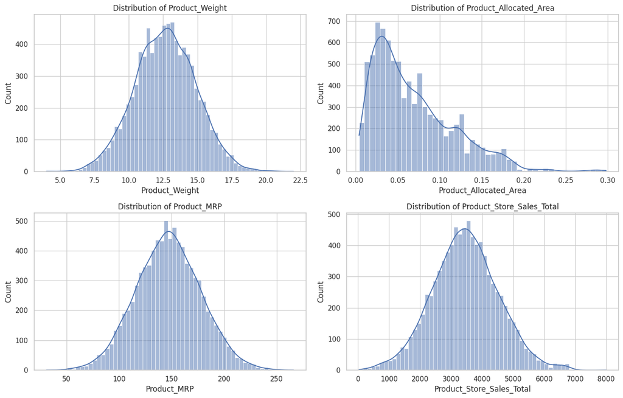

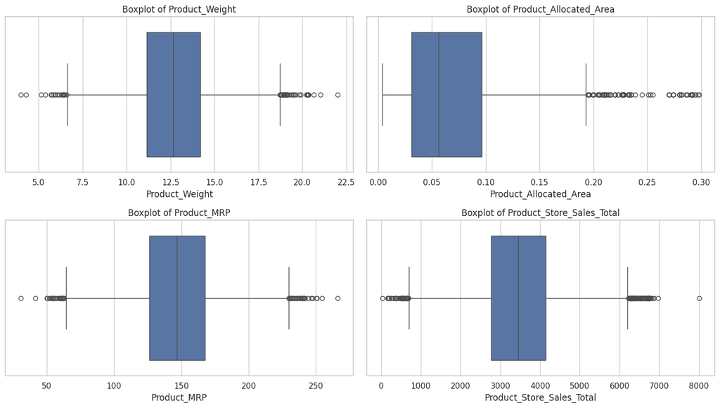

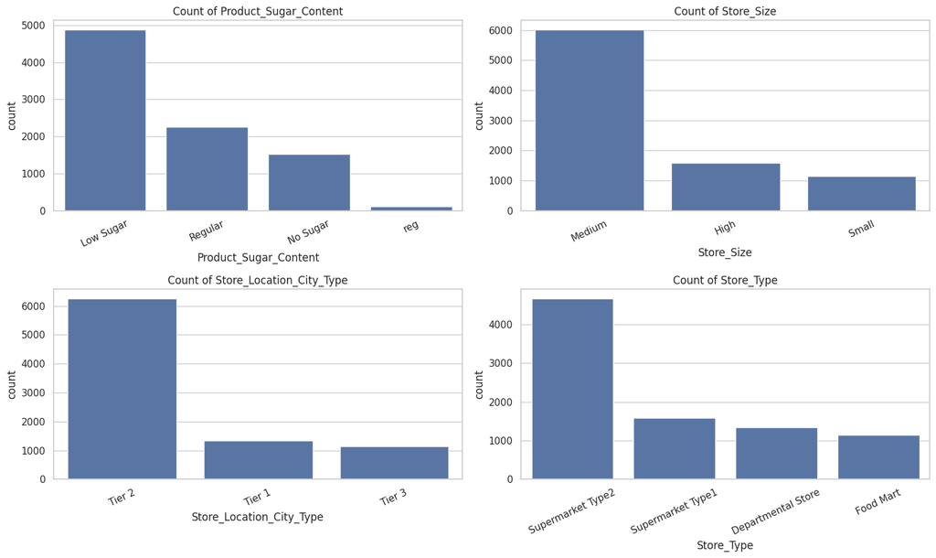

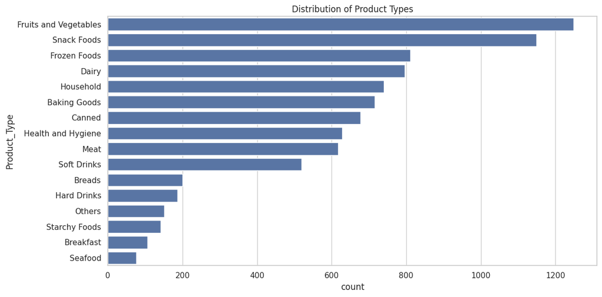

```
Skewness of numerical variables:
```

|  | Skewness |
| --- | --- |
| Product_Allocated_Area | 1.128093 |
| Product_Store_Sales_Total | 0.092024 |
| Product_MRP | 0.036513 |
| Product_Weight | 0.017514 |
| Store_Establishment_Year | -0.758061 |

```python
# Numerical distributions
numeric_eda = [
    "Product_Weight",
    "Product_Allocated_Area",
    "Product_MRP",
    "Product_Store_Sales_Total",
]

fig, axes = plt.subplots(2, 2, figsize=(14, 9))
for ax, col in zip(axes.flatten(), numeric_eda):
    sns.histplot(data=data, x=col, kde=True, ax=ax)
    ax.set_title(f"Distribution of {col}")
plt.tight_layout()
plt.show()

# Numerical boxplots
fig, axes = plt.subplots(2, 2, figsize=(14, 8))
for ax, col in zip(axes.flatten(), numeric_eda):
    sns.boxplot(data=data, x=col, ax=ax)
    ax.set_title(f"Boxplot of {col}")
plt.tight_layout()
plt.show()

# Key categorical distributions
categorical_eda = [
    "Product_Sugar_Content",
    "Store_Size",
    "Store_Location_City_Type",
    "Store_Type",
]

fig, axes = plt.subplots(2, 2, figsize=(15, 9))
for ax, col in zip(axes.flatten(), categorical_eda):
    order = data[col].value_counts().index
    sns.countplot(data=data, x=col, order=order, ax=ax)
    ax.set_title(f"Count of {col}")
    ax.tick_params(axis="x", rotation=25)
plt.tight_layout()
plt.show()

plt.figure(figsize=(12, 6))
order = data["Product_Type"].value_counts().index
sns.countplot(data=data, y="Product_Type", order=order)
plt.title("Distribution of Product Types")
plt.tight_layout()
plt.show()

# Skewness check
print("Skewness of numerical variables:")
display(
    data.select_dtypes(include=np.number)
        .skew()
        .sort_values(ascending=False)
        .to_frame("Skewness")
)
```

### Univariate Analysis — Observations

- **Target Variable Symmetry:** `Product_Store_Sales_Total` is approximately symmetric, with skewness close to **0.09**, so no target transformation is required.
- **Symmetric Features:** `Product_MRP` and `Product_Weight` are also close to symmetric, with skewness values near **zero**.
- **Positive Skewness:** `Product_Allocated_Area` is positively skewed, with skewness around **1.13**, indicating that most products receive relatively smaller allocated areas while a smaller number receive substantially larger areas.
- **Outlier Assessment:** The boxplots identify some extreme observations in numerical variables; however, the values remain **plausible** in a retail context rather than appearing to be data-entry errors.
- **Sugar Category Distribution:** `Low Sugar` is the most frequently occurring sugar category. The additional `reg` label is a **data-quality inconsistency** rather than a genuinely different category.
- **Store Representation:** Store-category frequencies are **not evenly distributed**. This reflects the number of product-store observations available for each store rather than a data-quality issue.

## Bivariate Analysis

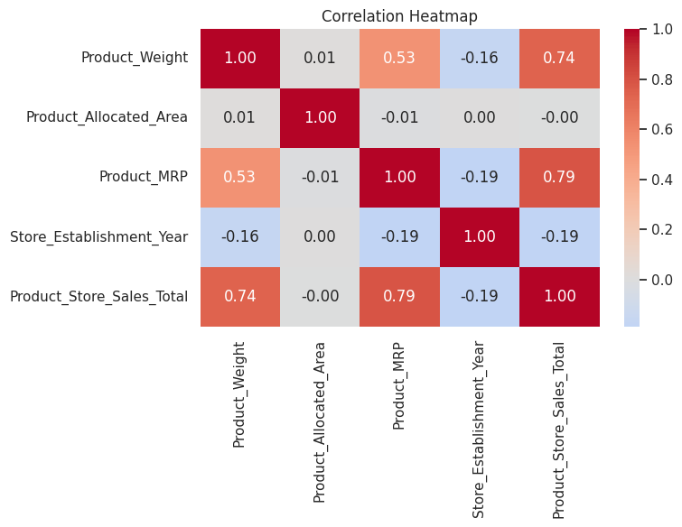

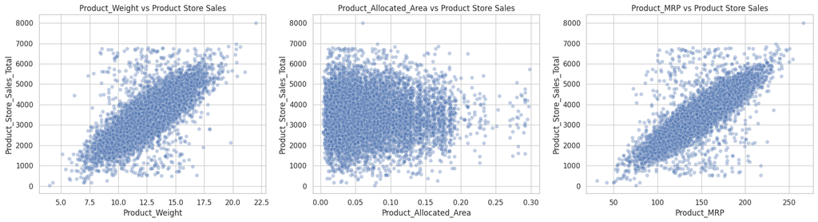

```
Sales summary by Store_Id
```

| Store_Id | Count | Average_Sales | Total_Sales |
| --- | --- | --- | --- |
| OUT003 | 1349 | 4946.966323 | 6673457.57 |
| OUT001 | 1586 | 3923.778802 | 6223113.18 |
| OUT004 | 4676 | 3299.312111 | 15427583.43 |
| OUT002 | 1152 | 1762.942465 | 2030909.72 |

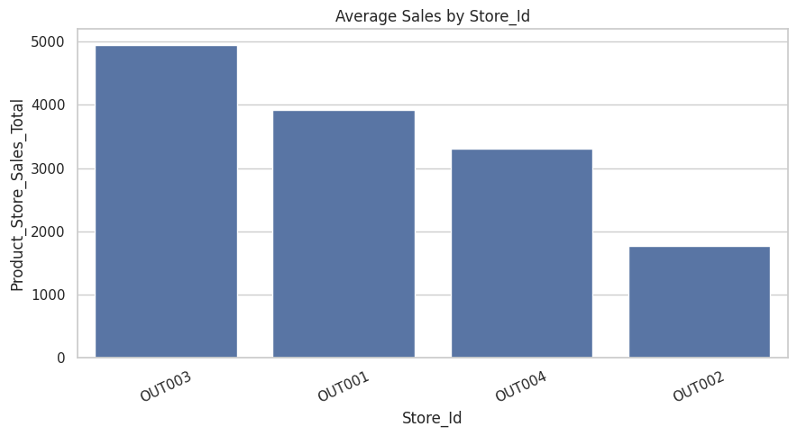

```
Sales summary by Store_Type
```

| Store_Type | Count | Average_Sales | Total_Sales |
| --- | --- | --- | --- |
| Departmental Store | 1349 | 4946.966323 | 6673457.57 |
| Supermarket Type1 | 1586 | 3923.778802 | 6223113.18 |
| Supermarket Type2 | 4676 | 3299.312111 | 15427583.43 |
| Food Mart | 1152 | 1762.942465 | 2030909.72 |

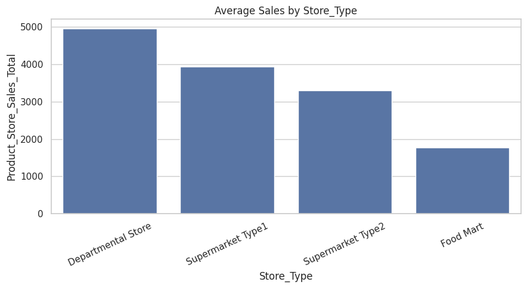

```
Sales summary by Store_Size
```

| Store_Size | Count | Average_Sales | Total_Sales |
| --- | --- | --- | --- |
| High | 1586 | 3923.778802 | 6223113.18 |
| Medium | 6025 | 3668.222573 | 22101041.00 |
| Small | 1152 | 1762.942465 | 2030909.72 |

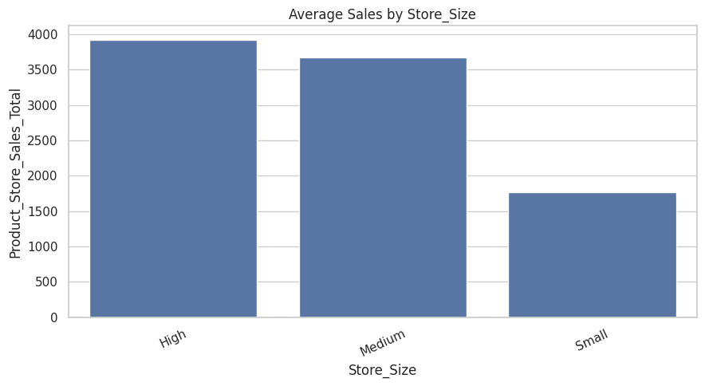

```
Sales summary by Store_Location_City_Type
```

| Store_Location_City_Type | Count | Average_Sales | Total_Sales |
| --- | --- | --- | --- |
| Tier 1 | 1349 | 4946.966323 | 6673457.57 |
| Tier 2 | 6262 | 3457.473109 | 21650696.61 |
| Tier 3 | 1152 | 1762.942465 | 2030909.72 |

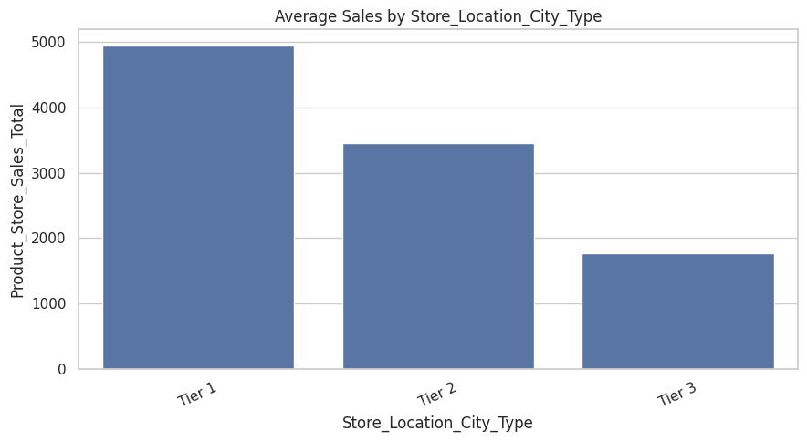

| Product_Type | Count | Average_Sales | Total_Sales |
| --- | --- | --- | --- |
| Starchy Foods | 141 | 3679.251418 | 518774.45 |
| Others | 151 | 3586.068212 | 541496.30 |
| Seafood | 76 | 3584.263684 | 272404.04 |
| Breads | 200 | 3574.711200 | 714942.24 |
| Dairy | 796 | 3532.560352 | 2811918.04 |
| Snack Foods | 1149 | 3471.711880 | 3988996.95 |
| Household | 740 | 3465.865095 | 2564740.17 |
| Frozen Foods | 811 | 3464.834562 | 2809980.83 |
| Soft Drinks | 519 | 3462.513911 | 1797044.72 |
| Health and Hygiene | 628 | 3445.393646 | 2163707.21 |
| Meat | 618 | 3445.326764 | 2129211.94 |
| Fruits and Vegetables | 1249 | 3443.421353 | 4300833.27 |
| Baking Goods | 716 | 3425.958101 | 2452986.00 |
| Breakfast | 106 | 3416.324623 | 362130.41 |
| Canned | 677 | 3397.463383 | 2300082.71 |
| Hard Drinks | 186 | 3364.594731 | 625814.62 |

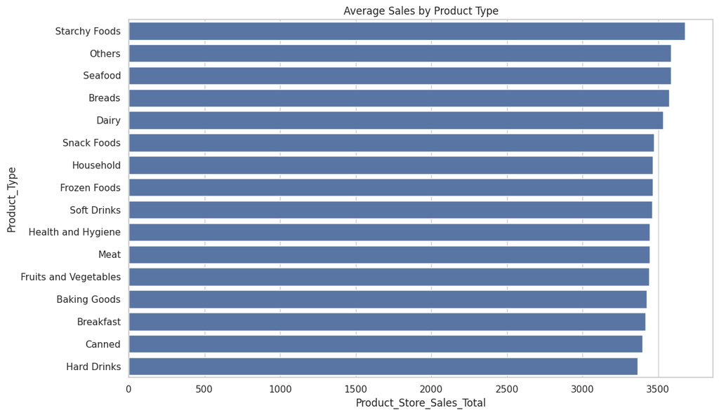

| Product_Sugar_Content | Count | Average_Sales | Total_Sales |
| --- | --- | --- | --- |
| Regular | 2359 | 3502.210437 | 8261714.42 |
| No Sugar | 1519 | 3469.350678 | 5269943.68 |
| Low Sugar | 4885 | 3443.890645 | 16823405.80 |

```python
# Correlation heatmap
plt.figure(figsize=(8, 6))
corr = data.select_dtypes(include=np.number).corr()
sns.heatmap(corr, annot=True, fmt=".2f", cmap="coolwarm", center=0)
plt.title("Correlation Heatmap")
plt.tight_layout()
plt.show()

# Numerical features vs target
fig, axes = plt.subplots(1, 3, figsize=(18, 5))
for ax, col in zip(
    axes,
    ["Product_Weight", "Product_Allocated_Area", "Product_MRP"],
):
    sns.scatterplot(
        data=data,
        x=col,
        y="Product_Store_Sales_Total",
        alpha=0.35,
        ax=ax,
    )
    ax.set_title(f"{col} vs Product Store Sales")
plt.tight_layout()
plt.show()

# Average and total sales by store-related features
for col in ["Store_Id", "Store_Type", "Store_Size", "Store_Location_City_Type"]:
    summary = (
        data.groupby(col, observed=False)["Product_Store_Sales_Total"]
        .agg(Count="count", Average_Sales="mean", Total_Sales="sum")
        .sort_values("Average_Sales", ascending=False)
    )
    print(f"\nSales summary by {col}")
    display(summary)

    plt.figure(figsize=(9, 5))
    sns.barplot(
        data=data,
        x=col,
        y="Product_Store_Sales_Total",
        order=summary.index,
        errorbar=None,
    )
    plt.title(f"Average Sales by {col}")
    plt.xticks(rotation=25)
    plt.tight_layout()
    plt.show()

# Average sales by product type
product_type_summary = (
    data.groupby("Product_Type", observed=False)["Product_Store_Sales_Total"]
    .agg(Count="count", Average_Sales="mean", Total_Sales="sum")
    .sort_values("Average_Sales", ascending=False)
)

display(product_type_summary)

plt.figure(figsize=(12, 7))
sns.barplot(
    data=data,
    y="Product_Type",
    x="Product_Store_Sales_Total",
    order=product_type_summary.index,
    errorbar=None,
)
plt.title("Average Sales by Product Type")
plt.tight_layout()
plt.show()

# Sugar content comparison after logically combining 'reg' and 'Regular'
sugar_eda = data.copy()
sugar_eda["Product_Sugar_Content"] = sugar_eda["Product_Sugar_Content"].replace(
    {"reg": "Regular"}
)

display(
    sugar_eda.groupby("Product_Sugar_Content")["Product_Store_Sales_Total"]
    .agg(Count="count", Average_Sales="mean", Total_Sales="sum")
    .sort_values("Average_Sales", ascending=False)
)
```

### Bivariate Analysis — Observations

- **Strongest Predictor:** `Product_MRP` has the strongest positive numerical relationship with sales, with a correlation of approximately **0.79** with `Product_Store_Sales_Total`.
- **Product Weight Impact:** `Product_Weight` also shows a strong positive relationship with sales, with a correlation around **0.74**.
- **Display Area Independence:** `Product_Allocated_Area` has **almost no linear relationship** with sales. Therefore, allocating a larger display area alone does not appear to guarantee greater product-store revenue.
- **Store Attribute Relevance:** Store-related attributes show clear differences in average sales, confirming their relevance for sales forecasting.
- **Format Performance Breakdown:** `Departmental Store` has the highest average product-store sales at approximately **4,947**, followed by `Supermarket Type1` at approximately **3,924**, `Supermarket Type2` at approximately **3,299**, and `Food Mart` at approximately **1,763**.
- **Volume vs. Productivity:** Although `Departmental Store` has the highest average sales, `Supermarket Type2` contributes the greatest total sales at approximately **15.43 million** because it contains substantially more product observations. This demonstrates the importance of distinguishing average productivity from total business contribution.
- **Store Predictive Context:** Differences across store type, city tier, and store size suggest that store characteristics contain **substantial predictive information** in addition to product characteristics.
- **Strategic EDA Takeaway:** Overall, the EDA indicates that both **product economics** (particularly MRP and weight) and **store context** are important drivers of sales.

# **Data Preprocessing**

```python
model_data = data.copy()

# 1. Correct inconsistent category label.
model_data["Product_Sugar_Content"] = model_data["Product_Sugar_Content"].replace(
    {"reg": "Regular"}
)

# 2. Product ID feature engineering.
# The full Product_Id is unique for every row, but the two-character prefix
# identifies a broader product family (FD, DR, NC).
model_data["Product_Id_char"] = model_data["Product_Id"].str[:2]

# 3. Store age feature engineering.
# The learner dataset/batch schema uses 2025 as the reference year.
model_data["Store_Age_Years"] = (
    2025 - model_data["Store_Establishment_Year"]
)

# 4. Group the 16 product types into operational perishability groups.
perishables = [
    "Dairy",
    "Meat",
    "Fruits and Vegetables",
    "Breakfast",
    "Breads",
    "Seafood",
]

model_data["Product_Type_Category"] = np.where(
    model_data["Product_Type"].isin(perishables),
    "Perishables",
    "Non Perishables",
)

# 5. Outlier detection using the IQR rule.
outlier_summary = []

for col in [
    "Product_Weight",
    "Product_Allocated_Area",
    "Product_MRP",
    "Product_Store_Sales_Total",
]:
    q1 = model_data[col].quantile(0.25)
    q3 = model_data[col].quantile(0.75)
    iqr = q3 - q1
    lower = q1 - 1.5 * iqr
    upper = q3 + 1.5 * iqr

    count = (
        (model_data[col] < lower) |
        (model_data[col] > upper)
    ).sum()

    outlier_summary.append(
        {
            "Feature": col,
            "Lower_Bound": lower,
            "Upper_Bound": upper,
            "Potential_Outliers": int(count),
        }
    )

outlier_summary = pd.DataFrame(outlier_summary)
display(outlier_summary)

# No outlier capping/removal is performed:
# - values are plausible retail observations rather than obvious data errors;
# - tree-based ensemble models are relatively robust to extreme values;
# - removing genuine high/low sales could reduce forecasting usefulness.

# 6. Deployment-aligned feature set.
# These are exactly the 10 columns supplied in Batch_Data_SuperKart.csv.
feature_cols = [
    "Product_Weight",
    "Product_Sugar_Content",
    "Product_Allocated_Area",
    "Product_MRP",
    "Store_Size",
    "Store_Location_City_Type",
    "Store_Type",
    "Product_Id_char",
    "Store_Age_Years",
    "Product_Type_Category",
]

target_col = "Product_Store_Sales_Total"

X = model_data[feature_cols].copy()
y = model_data[target_col].copy()

categorical_features = X.select_dtypes(include=["object", "category"]).columns.tolist()
numerical_features = X.select_dtypes(exclude=["object", "category"]).columns.tolist()

print("Categorical features:", categorical_features)
print("Numerical features:", numerical_features)

# 7. Hold-out test set.
X_train, X_test, y_train, y_test = train_test_split(
    X,
    y,
    test_size=0.20,
    random_state=RANDOM_STATE,
    shuffle=True,
)

print("\nTraining set shape:", X_train.shape)
print("Test set shape:", X_test.shape)

# 8. Preprocessing pipeline.
# IMPORTANT: numerical features are explicitly passed through.
# handle_unknown='ignore' also makes production inference robust to new labels.
preprocessor = ColumnTransformer(
    transformers=[
        (
            "categorical",
            OneHotEncoder(handle_unknown="ignore", sparse_output=False),
            categorical_features,
        ),
        ("numerical", "passthrough", numerical_features),
    ],
    remainder="drop",
)

preprocessor
```

|  | Feature | Lower_Bound | Upper_Bound | Potential_Outliers |
| --- | --- | --- | --- | --- |
| 0 | Product_Weight | 6.6050 | 18.7250 | 54 |
| 1 | Product_Allocated_Area | -0.0665 | 0.1935 | 104 |
| 2 | Product_MRP | 64.0225 | 229.7225 | 57 |
| 3 | Product_Store_Sales_Total | 686.5400 | 6220.3400 | 119 |

```
Categorical features: ['Product_Sugar_Content', 'Store_Size', 'Store_Location_City_Type', 'Store_Type', 'Product_Id_char', 'Product_Type_Category']
Numerical features: ['Product_Weight', 'Product_Allocated_Area', 'Product_MRP', 'Store_Age_Years']

Training set shape: (7010, 10)
Test set shape: (1753, 10)
```

```
ColumnTransformer(transformers=[('categorical',
                                 OneHotEncoder(handle_unknown='ignore',
                                               sparse_output=False),
                                 ['Product_Sugar_Content', 'Store_Size',
                                  'Store_Location_City_Type', 'Store_Type',
                                  'Product_Id_char', 'Product_Type_Category']),
                                ('numerical', 'passthrough',
                                 ['Product_Weight', 'Product_Allocated_Area',
                                  'Product_MRP', 'Store_Age_Years'])])
```

### Data Preprocessing — Observations and Rationale

- **Label Cleaning:** The inconsistent `reg` category is replaced with `Regular` to avoid treating the same business category as two different levels.
- **Feature Extraction:** Direct use of `Product_Id` is avoided because every value is unique. Instead, the first two characters are extracted into `Product_Id_char`, retaining the broader `FD`, `DR`, and `NC` product-family information with much lower cardinality.
- **Feature Engineering:** `Store_Establishment_Year` is converted into `Store_Age_Years` using the project reference year **2025**, providing a more interpretable representation of store maturity.
- **Categorical Simplification:** The original 16 product types are grouped into `Perishables` and `Non Perishables`, reducing categorical complexity and aligning the model inputs with the supplied batch-inference schema.
- **Outlier Strategy:** IQR analysis identifies 54 potential outliers in Product Weight, 104 in Product Allocated Area, 57 in Product MRP, and 119 in Product Store Sales Total. These observations are **retained** because they remain plausible retail values rather than obvious errors.
- **Model Robustness:** Retaining these observations is also reasonable because the selected tree-based ensemble models are relatively robust to extreme numerical values.
- **Schema Alignment:** The final model uses **10 deployment-aligned predictors**, matching the schema in `Batch_Data_SuperKart.csv`.
- **Deployment Safeguards:** Categorical predictors are transformed with `OneHotEncoder(handle_unknown="ignore")`, allowing the deployed pipeline to handle previously unseen category labels without failing.
- **Pipeline Choice:** Numerical variables are explicitly passed through the preprocessing pipeline. Scaling is **not required** because Random Forest and XGBoost are tree-based models and do not depend on feature magnitude in the way distance- or gradient-based linear methods do.

# **Model Building**

## Define functions for Model Evaluation

```python
def adj_r2_score(predictors, targets, predictions):
    """Compute adjusted R-squared using the raw predictor count."""
    r2 = r2_score(targets, predictions)
    n = predictors.shape[0]
    k = predictors.shape[1]

    if n <= k + 1:
        return np.nan

    return 1 - ((1 - r2) * (n - 1) / (n - k - 1))


def model_performance_regression(model, predictors, target):
    """Return common regression performance metrics."""
    pred = model.predict(predictors)

    return pd.DataFrame(
        {
            "RMSE": [np.sqrt(mean_squared_error(target, pred))],
            "MAE": [mean_absolute_error(target, pred)],
            "R-squared": [r2_score(target, pred)],
            "Adj. R-squared": [
                adj_r2_score(predictors, target, pred)
            ],
            "MAPE": [
                mean_absolute_percentage_error(target, pred)
            ],
        }
    )
```

The ML models to be built can be any two out of the following:

1. Decision Tree
2. Bagging
3. Random Forest
4. AdaBoost
5. Gradient Boosting
6. XGBoost

### Model Building — Metric Selection

- **Primary Metric:** **RMSE (Root Mean Squared Error)** is selected as the primary model-selection metric because the target, `Product_Store_Sales_Total`, is a continuous sales value.
- **Metric Rationale:** RMSE expresses prediction error in the same units as sales and penalises larger forecasting errors more strongly than smaller errors. This is appropriate for SuperKart because large under- or over-estimation of demand can result in stock-outs, excess inventory, and inefficient replenishment.
- **Supporting Measures:** `MAE`, `R-squared`, `Adjusted R-squared`, and `MAPE` are used as supporting measures to provide a broader understanding of model accuracy and generalisation.

```python
# Primary metric: RMSE
# RMSE is appropriate because the target is continuous sales revenue,
# it is interpretable in the same units as sales, and it penalizes large
# forecasting errors more strongly. Large errors are especially costly for
# inventory and supply-chain planning.
#
# MAE, R-squared and MAPE are reported as supporting diagnostics.

rf_pipeline = Pipeline(
    steps=[
        ("preprocessor", preprocessor),
        (
            "model",
            RandomForestRegressor(
                random_state=RANDOM_STATE,
                n_jobs=-1,
            ),
        ),
    ]
)

xgb_pipeline = Pipeline(
    steps=[
        ("preprocessor", preprocessor),
        (
            "model",
            XGBRegressor(
                objective="reg:squarederror",
                random_state=RANDOM_STATE,
                n_jobs=-1,
            ),
        ),
    ]
)

base_models = {
    "Random Forest - Base": rf_pipeline,
    "XGBoost - Base": xgb_pipeline,
}

base_summary = []
base_cv_rmse = {}

for model_name, model in base_models.items():
    print("\n" + "=" * 100)
    print(model_name)

    model.fit(X_train, y_train)

    train_perf = model_performance_regression(
        model,
        X_train,
        y_train,
    )

    cv_rmse = -cross_val_score(
        model,
        X_train,
        y_train,
        scoring="neg_root_mean_squared_error",
        cv=3,
        n_jobs=1,
    )

    base_cv_rmse[model_name] = cv_rmse.mean()

    row = {
        "Model": model_name,
        "Train_RMSE": train_perf.loc[0, "RMSE"],
        "Train_MAE": train_perf.loc[0, "MAE"],
        "Train_R2": train_perf.loc[0, "R-squared"],
        "CV_RMSE_Mean": cv_rmse.mean(),
        "CV_RMSE_Std": cv_rmse.std(),
    }
    base_summary.append(row)

base_summary_df = (
    pd.DataFrame(base_summary)
    .set_index("Model")
    .sort_values("CV_RMSE_Mean")
)

print("\nBASE MODEL COMPARISON")
display(base_summary_df)
```

```
====================================================================================================
Random Forest - Base

====================================================================================================
XGBoost - Base

BASE MODEL COMPARISON
```

| Model | Train_RMSE | Train_MAE | Train_R2 | CV_RMSE_Mean | CV_RMSE_Std |
| --- | --- | --- | --- | --- | --- |
| Random Forest - Base | 106.895590 | 40.167088 | 0.989924 | 291.366013 | 7.174249 |
| XGBoost - Base | 139.413459 | 63.001258 | 0.982861 | 304.515262 | 7.591609 |

### Base Model Performance — Observation

- **Evaluated Algorithms:** Two ensemble regression algorithms were evaluated: **Random Forest Regressor** and **XGBoost Regressor**.
- **Base Random Forest Performance:**
  - Training RMSE: **106.90** | MAE: **40.17** | R-squared: **0.9899**
  - 3-Fold Cross-Validation RMSE: **291.37 ± 7.17**
- **Base XGBoost Performance:**
  - Training RMSE: **139.41** | MAE: **63.00** | R-squared: **0.9829**
  - 3-Fold Cross-Validation RMSE: **304.52 ± 7.59**
- **Baseline Comparison:** Based on cross-validation, the base Random Forest clearly outperformed the base XGBoost model with a lower average RMSE.
- **Overfitting Risk:** Both models perform considerably better on the training data than during cross-validation, indicating some degree of overfitting. This is particularly visible for the Random Forest, whose training R-squared is close to **0.99**.
- **Next Steps:** Because cross-validation performance provides a more realistic indication of generalisation than training performance, hyperparameter tuning is performed next.

# **Model Performance Improvement - Hyperparameter Tuning**

```python
# Hyperparameter tuning is performed using the same primary metric:
# cross-validated RMSE (lower is better).

rf_param_grid = {
    "model__n_estimators": [100, 200],
    "model__max_depth": [None, 12],
    "model__min_samples_leaf": [1, 2],
    "model__max_features": [1.0, 0.8],
}

xgb_param_grid = {
    "model__n_estimators": [200, 400],
    "model__max_depth": [2, 3],
    "model__learning_rate": [0.03, 0.05],
    "model__subsample": [0.9, 1.0],
}

rf_grid = GridSearchCV(
    estimator=Pipeline(
        steps=[
            ("preprocessor", preprocessor),
            (
                "model",
                RandomForestRegressor(
                    random_state=RANDOM_STATE,
                    n_jobs=1,
                ),
            ),
        ]
    ),
    param_grid=rf_param_grid,
    scoring="neg_root_mean_squared_error",
    cv=3,
    n_jobs=-1,
    refit=True,
    verbose=1,
)

xgb_grid = GridSearchCV(
    estimator=Pipeline(
        steps=[
            ("preprocessor", preprocessor),
            (
                "model",
                XGBRegressor(
                    objective="reg:squarederror",
                    random_state=RANDOM_STATE,
                    n_jobs=1,
                ),
            ),
        ]
    ),
    param_grid=xgb_param_grid,
    scoring="neg_root_mean_squared_error",
    cv=3,
    n_jobs=-1,
    refit=True,
    verbose=1,
)

print("Tuning Random Forest...")
rf_grid.fit(X_train, y_train)

print("\nBest Random Forest parameters:")
print(rf_grid.best_params_)
print(f"Best Random Forest CV RMSE: {-rf_grid.best_score_:.3f}")

print("\nTuning XGBoost...")
xgb_grid.fit(X_train, y_train)

print("\nBest XGBoost parameters:")
print(xgb_grid.best_params_)
print(f"Best XGBoost CV RMSE: {-xgb_grid.best_score_:.3f}")

tuned_models = {
    "Random Forest - Tuned": rf_grid.best_estimator_,
    "XGBoost - Tuned": xgb_grid.best_estimator_,
}

tuned_summary = []

for model_name, model in tuned_models.items():
    train_perf = model_performance_regression(
        model,
        X_train,
        y_train,
    )

    best_cv = (
        -rf_grid.best_score_
        if "Random Forest" in model_name
        else -xgb_grid.best_score_
    )

    tuned_summary.append(
        {
            "Model": model_name,
            "Train_RMSE": train_perf.loc[0, "RMSE"],
            "Train_MAE": train_perf.loc[0, "MAE"],
            "Train_R2": train_perf.loc[0, "R-squared"],
            "CV_RMSE_Mean": best_cv,
        }
    )

tuned_summary_df = (
    pd.DataFrame(tuned_summary)
    .set_index("Model")
    .sort_values("CV_RMSE_Mean")
)

print("\nTUNED MODEL COMPARISON")
display(tuned_summary_df)
```

```
Tuning Random Forest...
Fitting 3 folds for each of 16 candidates, totalling 48 fits

Best Random Forest parameters:
{'model__max_depth': None, 'model__max_features': 0.8, 'model__min_samples_leaf': 2, 'model__n_estimators': 200}
Best Random Forest CV RMSE: 286.047

Tuning XGBoost...
Fitting 3 folds for each of 16 candidates, totalling 48 fits

Best XGBoost parameters:
{'model__learning_rate': 0.05, 'model__max_depth': 3, 'model__n_estimators': 400, 'model__subsample': 0.9}
Best XGBoost CV RMSE: 304.590

TUNED MODEL COMPARISON
```

| Model | Train_RMSE | Train_MAE | Train_R2 | CV_RMSE_Mean |
| --- | --- | --- | --- | --- |
| Random Forest - Tuned | 172.487686 | 61.449635 | 0.973765 | 286.047283 |
| XGBoost - Tuned | 276.527912 | 115.098075 | 0.932571 | 304.590060 |

### Hyperparameter Tuning — Observation

- **Tuning Setup:** `GridSearchCV` was used to tune both ensemble models using **3-fold cross-validation and RMSE**, ensuring that the tuning objective remains consistent with the primary evaluation metric.
- **Optimal Random Forest Parameters:**
  - `max_depth = None` | `max_features = 0.8` | `min_samples_leaf = 2` | `n_estimators = 200`
- **Tuned Random Forest Performance:**
  - Training RMSE: **172.49** | MAE: **61.45** | R-squared: **0.9738**
  - Cross-Validation RMSE: **286.05**
- **Random Forest Improvement:** The tuned Random Forest improved cross-validation RMSE from **291.37 to 286.05** (an improvement of approximately **1.8%**). Concurrently, its training performance became less extreme than the base model, indicating that tuning helped reduce overfitting while improving generalisation.
- **Optimal XGBoost Parameters:**
  - `learning_rate = 0.05` | `max_depth = 3` | `n_estimators = 400` | `subsample = 0.9`
- **Tuned XGBoost Performance:**
  - Training RMSE: **276.53** | MAE: **115.10** | R-squared: **0.9326**
  - Cross-Validation RMSE: **304.59**
- **XGBoost Evaluation:** The tuned XGBoost did not improve upon the base XGBoost CV RMSE of **304.52**. This demonstrates that hyperparameter tuning does not automatically improve a model and reinforces the importance of selecting models based on objective validation performance.

# **Model Performance Comparison, Final Model Selection, and Serialization**

|  | Model | CV_RMSE |
| --- | --- | --- |
| 0 | Random Forest - Tuned | 286.047283 |
| 1 | Random Forest - Base | 291.366013 |
| 2 | XGBoost - Base | 304.515262 |
| 3 | XGBoost - Tuned | 304.590060 |

```
Selected final model: Random Forest - Tuned
Selection rationale: lowest 3-fold cross-validated RMSE among all four candidate pipelines.

FINAL MODEL TEST PERFORMANCE
```

|  | RMSE | MAE | R-squared | Adj. R-squared | MAPE |
| --- | --- | --- | --- | --- | --- |
| Random Forest - Tuned | 279.179296 | 107.010162 | 0.931692 | 0.9313 | 0.038666 |

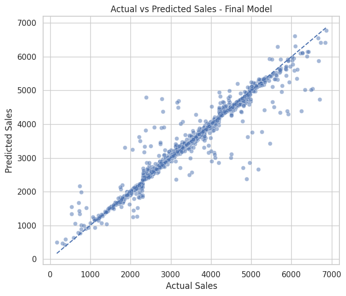

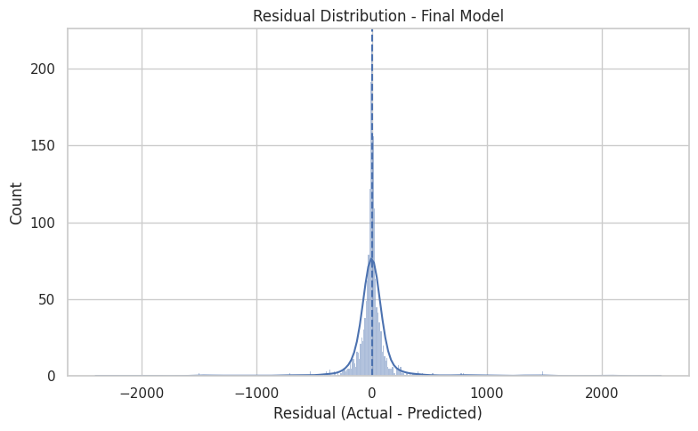

```
Serialized model saved to: backend_files/superkart_model.joblib
Reloaded model produces identical predictions: True
```

|  | Actual | Predicted | Absolute_Error |
| --- | --- | --- | --- |
| 0 | 3396.37 | 3381.553083 | 14.816917 |
| 1 | 3371.45 | 3363.629052 | 7.820948 |
| 2 | 2416.69 | 2418.122235 | 1.432235 |
| 3 | 1910.53 | 1902.814149 | 7.715851 |
| 4 | 3191.08 | 4687.834788 | 1496.754788 |
| 5 | 2933.24 | 2987.592746 | 54.352746 |
| 6 | 2872.85 | 2871.105730 | 1.744270 |
| 7 | 3177.22 | 3106.114168 | 71.105832 |
| 8 | 3194.42 | 3300.131625 | 105.711625 |
| 9 | 539.71 | 1553.247312 | 1013.537312 |

```
Top 15 final-model feature importances
```

|  | Feature | Importance |
| --- | --- | --- |
| 0 | numerical__Product_MRP | 0.402131 |
| 1 | numerical__Product_Weight | 0.105990 |
| 2 | categorical__Store_Type_Food Mart | 0.089694 |
| 3 | categorical__Store_Location_City_Type_Tier 3 | 0.088919 |
| 4 | categorical__Store_Size_Small | 0.074865 |
| 5 | categorical__Store_Location_City_Type_Tier 1 | 0.048789 |
| 6 | categorical__Store_Location_City_Type_Tier 2 | 0.047150 |
| 7 | categorical__Store_Type_Departmental Store | 0.045644 |
| 8 | numerical__Store_Age_Years | 0.037416 |
| 9 | categorical__Store_Type_Supermarket Type2 | 0.021617 |
| 10 | categorical__Store_Type_Supermarket Type1 | 0.009150 |
| 11 | numerical__Product_Allocated_Area | 0.008457 |
| 12 | categorical__Store_Size_Medium | 0.008091 |
| 13 | categorical__Store_Size_High | 0.007932 |
| 14 | categorical__Product_Sugar_Content_Low Sugar | 0.000783 |

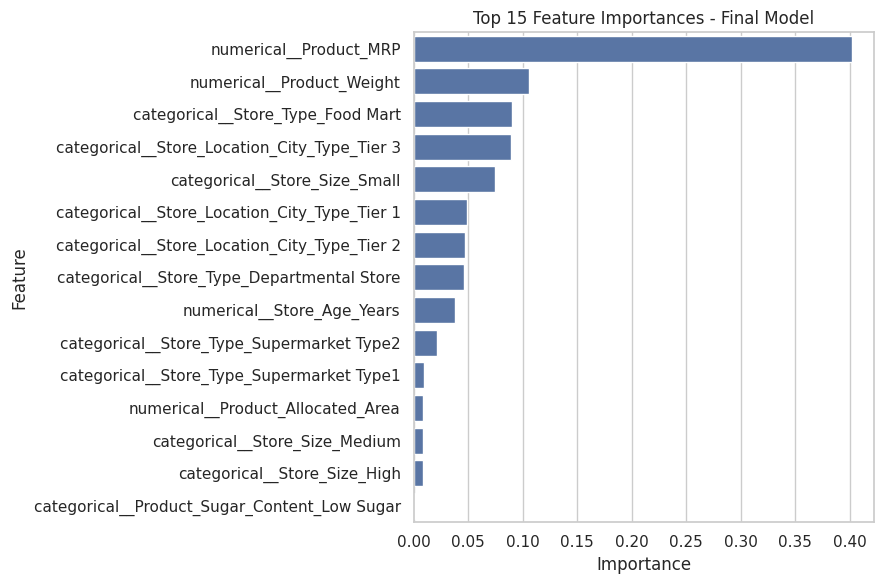

```python
# Compare all candidate models using training-data cross-validation.
# This avoids repeatedly using the test set to choose a model.

model_comparison = pd.DataFrame(
    [
        {
            "Model": "Random Forest - Base",
            "CV_RMSE": base_cv_rmse["Random Forest - Base"],
        },
        {
            "Model": "XGBoost - Base",
            "CV_RMSE": base_cv_rmse["XGBoost - Base"],
        },
        {
            "Model": "Random Forest - Tuned",
            "CV_RMSE": -rf_grid.best_score_,
        },
        {
            "Model": "XGBoost - Tuned",
            "CV_RMSE": -xgb_grid.best_score_,
        },
    ]
).sort_values("CV_RMSE").reset_index(drop=True)

display(model_comparison)

candidate_models = {
    "Random Forest - Base": rf_pipeline,
    "XGBoost - Base": xgb_pipeline,
    "Random Forest - Tuned": rf_grid.best_estimator_,
    "XGBoost - Tuned": xgb_grid.best_estimator_,
}

best_model_name = model_comparison.loc[0, "Model"]
final_model = candidate_models[best_model_name]

print(f"Selected final model: {best_model_name}")
print(
    "Selection rationale: lowest 3-fold cross-validated RMSE "
    "among all four candidate pipelines."
)

# Final evaluation on the untouched test set.
final_test_perf = model_performance_regression(
    final_model,
    X_test,
    y_test,
)

final_test_perf.index = [best_model_name]

print("\nFINAL MODEL TEST PERFORMANCE")
display(final_test_perf)

test_predictions = final_model.predict(X_test)

# Actual vs predicted plot
plt.figure(figsize=(7, 6))
sns.scatterplot(x=y_test, y=test_predictions, alpha=0.5)
lims = [
    min(y_test.min(), test_predictions.min()),
    max(y_test.max(), test_predictions.max()),
]
plt.plot(lims, lims, "--")
plt.xlabel("Actual Sales")
plt.ylabel("Predicted Sales")
plt.title("Actual vs Predicted Sales - Final Model")
plt.tight_layout()
plt.show()

# Residual diagnostics
residuals = y_test - test_predictions

plt.figure(figsize=(8, 5))
sns.histplot(residuals, kde=True)
plt.axvline(0, linestyle="--")
plt.xlabel("Residual (Actual - Predicted)")
plt.title("Residual Distribution - Final Model")
plt.tight_layout()
plt.show()

# Serialize the COMPLETE preprocessing + model pipeline.
os.makedirs("backend_files", exist_ok=True)
os.makedirs("frontend_files", exist_ok=True)

MODEL_PATH = "backend_files/superkart_model.joblib"
joblib.dump(final_model, MODEL_PATH)

print(f"Serialized model saved to: {MODEL_PATH}")

# Reload and verify serialization.
loaded_model = joblib.load(MODEL_PATH)
reloaded_predictions = loaded_model.predict(X_test)

print(
    "Reloaded model produces identical predictions:",
    np.allclose(test_predictions, reloaded_predictions),
)

display(
    pd.DataFrame(
        {
            "Actual": y_test.iloc[:10].values,
            "Predicted": reloaded_predictions[:10],
            "Absolute_Error": np.abs(
                y_test.iloc[:10].values - reloaded_predictions[:10]
            ),
        }
    )
)

# Optional feature-importance analysis for a tree model.
fitted_preprocessor = final_model.named_steps["preprocessor"]
fitted_estimator = final_model.named_steps["model"]

if hasattr(fitted_estimator, "feature_importances_"):
    transformed_names = fitted_preprocessor.get_feature_names_out()

    feature_importance = (
        pd.DataFrame(
            {
                "Feature": transformed_names,
                "Importance": fitted_estimator.feature_importances_,
            }
        )
        .sort_values("Importance", ascending=False)
        .reset_index(drop=True)
    )

    print("\nTop 15 final-model feature importances")
    display(feature_importance.head(15))

    plt.figure(figsize=(9, 6))
    sns.barplot(
        data=feature_importance.head(15),
        x="Importance",
        y="Feature",
    )
    plt.title("Top 15 Feature Importances - Final Model")
    plt.tight_layout()
    plt.show()
```

### Model Comparison and Final Model Selection — Observations

| Rank | Model Candidate | Cross-Validation RMSE | Status |
| --- | --- | --- | --- |
| **1** | **Random Forest - Tuned** | **286.05** | **Selected Final Model** |
| **2** | Random Forest - Base | 291.37 | Overfitted baseline |
| **3** | XGBoost - Base | 304.52 | Baseline alternative |
| **4** | XGBoost - Tuned | 304.59 | Underperformed tuning |

- **Selection Rationale:** **Tuned Random Forest** is selected as the final model because it achieved the lowest cross-validated RMSE and showed a better balance between fit and generalisation than the base Random Forest.
- **Validation Integrity:** Model selection was performed using cross-validation on the training data rather than repeatedly evaluating alternatives on the held-out test data. This preserves the test set as a genuinely unseen final assessment.

### Final Model Test Performance — Observations

- **Holdout Test Set Performance:** On the untouched test dataset, the selected Tuned Random Forest achieved:
  - **RMSE:** **279.18**
  - **MAE:** **107.01**
  - **R-squared:** **0.9317**
  - **Adjusted R-squared:** **0.9313**
  - **MAPE:** **0.0387** (approximately **3.87%**)
- **Variance Explained:** An R-squared of approximately **0.932** indicates that the model explains about **93.2% of the variation in unseen product-store sales**, representing strong predictive performance.
- **Generalisation Evidence:** The test RMSE of **279.18** is slightly lower than the model's cross-validation RMSE of **286.05**, indicating that performance on the held-out sample is consistent with, and slightly better than, the cross-validation estimate. This provides good evidence that the model generalises well rather than being dependent on a favourable training split.
- **Error Metrics Interpretation:** The MAE of approximately **107** indicates that the model's predictions differ from actual sales by about 107 sales units on average, while the MAPE of approximately **3.87%** suggests a low average percentage error.
- **Residual Analysis:** The *Actual vs Predicted* plot shows predictions concentrated near the ideal diagonal for most observations. A small number of larger residuals remain, which is expected in real-world sales forecasting and explains why RMSE is noticeably larger than MAE.

### Model Serialization and Validation — Observations

- **Persistence Strategy:** The complete Tuned Random Forest pipeline, including both preprocessing and the fitted estimator, was serialized using `joblib`.
- **Integrity Check:** After reloading the model from disk, the comparison returned: **`Reloaded model produces identical predictions: True`**.
- **Deployment Validation:** This confirms that model serialization preserved the fitted pipeline correctly and that the deployment version generates the same predictions as the model evaluated in the notebook.

### Feature Importance — Observations

- **Dominant Feature:** `Product_MRP` is by far the most influential individual feature, contributing approximately **40.2%** of total model importance.
- **Secondary Numeric Feature:** `Product_Weight` is the second most important numerical feature at approximately **10.6%**.
- **Store Predictors:** Important store-related predictors include `Food Mart` store type (**~9.0%**), `Tier 3` location (**~8.9%**), `Small` store size (**~7.5%**), and `Departmental Store` type (**~4.6%**).
- **Store Maturity:** `Store_Age_Years` also contributes predictive information, with an importance of approximately **3.7%**.
- **Low Impact Feature:** `Product_Allocated_Area` has relatively low importance at below **1%**, which is consistent with its weak relationship with sales observed during EDA.
- **Consolidated Conclusion:** Overall, the importance results support the earlier exploratory findings: **price/product characteristics and store context are the dominant drivers of predicted sales**.
- **Interpretation Warning:** Because several store attributes describe related aspects of the same store, their individual importance values should be interpreted collectively rather than as completely independent causal effects.

# **Deployment - Backend**

## Points to note before executing the below cells

- Create a GitHub account if you don't already have one at github.com
- Generate a **Personal Access Token**
  - Make sure the token has **repo** scope (full control of private repositories)
- The serialized ML model file (`superkart_model.joblib`) should already be present in the `backend_files` folder before pushing to GitHub
- We will deploy **both the Flask backend and the Streamlit frontend as separate Docker containers** inside a GitHub Codespace, and connect them using a **Docker network**

## Flask Web Framework

Flask is a lightweight, flexible Python web framework used to build web applications and APIs quickly and easily.

Flask allows you to:

- Create web routes (URLs that users can access)
- Handle HTTP requests and responses
- Build REST APIs to expose machine learning models or other services

```python
backend_app = r"""
import os
import joblib
import pandas as pd
from flask import Flask, request, jsonify

superkart_api = Flask("superkart_api")

MODEL_PATH = os.path.join(
    os.path.dirname(os.path.abspath(__file__)),
    "superkart_model.joblib",
)

model = joblib.load(MODEL_PATH)

EXPECTED_FEATURES = [
    "Product_Weight",
    "Product_Sugar_Content",
    "Product_Allocated_Area",
    "Product_MRP",
    "Store_Size",
    "Store_Location_City_Type",
    "Store_Type",
    "Product_Id_char",
    "Store_Age_Years",
    "Product_Type_Category",
]


def validate_input(df):
    missing = [c for c in EXPECTED_FEATURES if c not in df.columns]
    if missing:
        raise ValueError(f"Missing required columns: {missing}")

    df = df[EXPECTED_FEATURES].copy()

    # Defensive cleaning for the known training-data label inconsistency.
    df["Product_Sugar_Content"] = df["Product_Sugar_Content"].replace(
        {"reg": "Regular"}
    )

    numeric_cols = [
        "Product_Weight",
        "Product_Allocated_Area",
        "Product_MRP",
        "Store_Age_Years",
    ]

    for col in numeric_cols:
        df[col] = pd.to_numeric(df[col], errors="raise")

    return df


@superkart_api.get("/")
def home():
    return jsonify(
        {
            "status": "ok",
            "message": "Welcome to the SuperKart Sales Prediction API",
            "single_prediction": "/v1/predict",
            "batch_prediction": "/v1/predictbatch",
        }
    )


@superkart_api.post("/v1/predict")
def predict_sales():
    try:
        payload = request.get_json(force=True)

        if not isinstance(payload, dict):
            return jsonify({"error": "A JSON object is required"}), 400

        input_df = validate_input(pd.DataFrame([payload]))
        prediction = float(model.predict(input_df)[0])

        return jsonify({"Sales": prediction})

    except Exception as exc:
        return jsonify({"error": str(exc)}), 400


@superkart_api.post("/v1/predictbatch")
def predict_batch():
    try:
        if "file" not in request.files:
            return jsonify(
                {"error": "Upload a CSV using form field 'file'"}
            ), 400

        batch_df = pd.read_csv(request.files["file"])
        batch_df = validate_input(batch_df)

        predictions = model.predict(batch_df)

        return jsonify(
            {
                str(i): float(pred)
                for i, pred in enumerate(predictions)
            }
        )

    except Exception as exc:
        return jsonify({"error": str(exc)}), 400


if __name__ == "__main__":
    superkart_api.run(host="0.0.0.0", port=7860)
"""

with open("backend_files/app.py", "w", encoding="utf-8") as f:
    f.write(backend_app)

print("Created backend_files/app.py")
```

```
Created backend_files/app.py
```

## Dependencies File

```python
backend_requirements = """\
numpy==2.0.2
pandas==2.2.2
scikit-learn==1.6.1
joblib==1.4.2
xgboost==2.1.4
Flask==3.1.0
gunicorn==23.0.0
"""

with open("backend_files/requirements.txt", "w", encoding="utf-8") as f:
    f.write(backend_requirements)

print("Created backend_files/requirements.txt")
```

```
Created backend_files/requirements.txt
```

## Dockerfile

```python
backend_dockerfile = """\
FROM python:3.11-slim

WORKDIR /app

COPY requirements.txt .
RUN pip install --no-cache-dir -r requirements.txt

COPY app.py .
COPY superkart_model.joblib .

EXPOSE 7860

CMD ["gunicorn", "--bind", "0.0.0.0:7860", "--workers", "2", "--timeout", "120", "app:superkart_api"]
"""

with open("backend_files/Dockerfile", "w", encoding="utf-8") as f:
    f.write(backend_dockerfile)

print("Created backend_files/Dockerfile")
```

```
Created backend_files/Dockerfile
```

# **Deployment - Frontend**

## Streamlit for Interactive UI

```python
frontend_app = r"""
import os
import pandas as pd
import requests
import streamlit as st

st.set_page_config(
    page_title="SuperKart Sales Forecast",
    page_icon="🛒",
    layout="wide",
)

st.title("🛒 SuperKart Sales Forecast")
st.write(
    "Forecast product-store sales using the deployed SuperKart model."
)

DEFAULT_BACKEND_URL = os.getenv(
    "BACKEND_URL",
    "http://superkart-backend:7860",
)

backend_url = st.sidebar.text_input(
    "Backend API URL",
    value=DEFAULT_BACKEND_URL,
).rstrip("/")

single_tab, batch_tab = st.tabs(
    ["Single Prediction", "Batch Prediction"]
)

with single_tab:
    st.subheader("Single Prediction")

    col1, col2 = st.columns(2)

    with col1:
        Product_Weight = st.number_input(
            "Product Weight",
            min_value=0.0,
            value=12.66,
            step=0.1,
        )

        Product_Sugar_Content = st.selectbox(
            "Product Sugar Content",
            ["Low Sugar", "Regular", "No Sugar"],
        )

        Product_Allocated_Area = st.number_input(
            "Product Allocated Area",
            min_value=0.0,
            max_value=1.0,
            value=0.027,
            step=0.001,
            format="%.3f",
        )

        Product_MRP = st.number_input(
            "Product MRP",
            min_value=0.0,
            value=117.08,
            step=1.0,
        )

        Store_Size = st.selectbox(
            "Store Size",
            ["Small", "Medium", "High"],
            index=1,
        )

    with col2:
        Store_Location_City_Type = st.selectbox(
            "Store Location City Type",
            ["Tier 1", "Tier 2", "Tier 3"],
            index=1,
        )

        Store_Type = st.selectbox(
            "Store Type",
            [
                "Departmental Store",
                "Supermarket Type1",
                "Supermarket Type2",
                "Food Mart",
                "Supermarket Type3",
            ],
            index=2,
        )

        Product_Id_char = st.selectbox(
            "Product ID Prefix",
            ["FD", "DR", "NC"],
        )

        Store_Age_Years = st.number_input(
            "Store Age (Years; reference year 2025)",
            min_value=0,
            max_value=100,
            value=16,
            step=1,
        )

        Product_Type_Category = st.selectbox(
            "Product Type Category",
            ["Perishables", "Non Perishables"],
        )

    payload = {
        "Product_Weight": Product_Weight,
        "Product_Sugar_Content": Product_Sugar_Content,
        "Product_Allocated_Area": Product_Allocated_Area,
        "Product_MRP": Product_MRP,
        "Store_Size": Store_Size,
        "Store_Location_City_Type": Store_Location_City_Type,
        "Store_Type": Store_Type,
        "Product_Id_char": Product_Id_char,
        "Store_Age_Years": Store_Age_Years,
        "Product_Type_Category": Product_Type_Category,
    }

    if st.button("Predict Sales", type="primary"):
        try:
            response = requests.post(
                f"{backend_url}/v1/predict",
                json=payload,
                timeout=60,
            )
            response.raise_for_status()
            result = response.json()

            st.success(
                f"Predicted Product-Store Sales Total: "
                f"{result['Sales']:,.2f}"
            )

        except Exception as exc:
            st.error(f"Prediction request failed: {exc}")

with batch_tab:
    st.subheader("Batch Prediction")

    st.caption(
        "Upload a CSV with the 10 model input columns."
    )

    uploaded_file = st.file_uploader(
        "Upload CSV",
        type=["csv"],
    )

    if uploaded_file is not None:
        batch_df = pd.read_csv(uploaded_file)
        st.dataframe(batch_df.head())

        if st.button("Run Batch Prediction"):
            try:
                csv_bytes = batch_df.to_csv(
                    index=False
                ).encode("utf-8")

                response = requests.post(
                    f"{backend_url}/v1/predictbatch",
                    files={
                        "file": (
                            "batch.csv",
                            csv_bytes,
                            "text/csv",
                        )
                    },
                    timeout=120,
                )

                response.raise_for_status()
                pred_dict = response.json()

                result_df = batch_df.copy()
                result_df["Predicted_Sales"] = [
                    pred_dict[str(i)]
                    for i in range(len(batch_df))
                ]

                st.success("Batch prediction completed.")
                st.dataframe(result_df)

                st.download_button(
                    "Download Predictions",
                    data=result_df.to_csv(
                        index=False
                    ).encode("utf-8"),
                    file_name="superkart_predictions.csv",
                    mime="text/csv",
                )

            except Exception as exc:
                st.error(f"Batch prediction failed: {exc}")
"""

with open("frontend_files/app.py", "w", encoding="utf-8") as f:
    f.write(frontend_app)

print("Created frontend_files/app.py")
```

```
Created frontend_files/app.py
```

## Dependencies File

```python
frontend_requirements = """\
pandas==2.2.2
requests==2.32.4
streamlit==1.44.1
"""

with open("frontend_files/requirements.txt", "w", encoding="utf-8") as f:
    f.write(frontend_requirements)

print("Created frontend_files/requirements.txt")
```

```
Created frontend_files/requirements.txt
```

## Dockerfile

```python
frontend_dockerfile = """\
FROM python:3.11-slim

WORKDIR /app

COPY requirements.txt .
RUN pip install --no-cache-dir -r requirements.txt

COPY app.py .

EXPOSE 8501

CMD ["streamlit", "run", "app.py", "--server.address=0.0.0.0", "--server.port=8501"]
"""

with open("frontend_files/Dockerfile", "w", encoding="utf-8") as f:
    f.write(frontend_dockerfile)

print("Created frontend_files/Dockerfile")
```

```
Created frontend_files/Dockerfile
```

# **Pushing Deployment Files to GitHub**

```python
# ------------------------------------------------------------
# Safe / repeatable GitHub push helper
# ------------------------------------------------------------
# This cell is designed to work even if:
# - /content is already a Git repository
# - files were committed in an earlier run
# - there are unrelated Colab folders such as .config/, drive/, sample_data/
#
# IMPORTANT:
# 1. Create the GitHub repository first.
# 2. Use a NEW GitHub PAT when prompted.
# 3. Do not hard-code the token in the notebook.

GITHUB_USERNAME = "click2shivesh"
#GITHUB_REPOSITORY = "shivesh-uta-aiml-py"
GITHUB_REPOSITORY = "superkart-deployment"
RUN_GITHUB_PUSH = True

if RUN_GITHUB_PUSH:
    from getpass import getpass
    import os
    import subprocess

    # Make sure the deployment folders actually exist.
    required_paths = ["backend_files", "frontend_files"]

    missing_paths = [
        p for p in required_paths
        if not os.path.exists(p)
    ]

    if missing_paths:
        raise FileNotFoundError(
            "Missing deployment folders: "
            + ", ".join(missing_paths)
            + ". Run the backend/frontend creation cells first."
        )

    # Avoid accidentally tracking Colab/Drive folders.
    gitignore_content = """\
.config/
drive/
sample_data/
__pycache__/
*.pyc
.ipynb_checkpoints/
"""

    with open(".gitignore", "w", encoding="utf-8") as f:
        f.write(gitignore_content)

    def run_git(args, check=True):
        result = subprocess.run(
            ["git"] + args,
            capture_output=True,
            text=True,
        )

        if result.stdout.strip():
            print(result.stdout.strip())

        if result.stderr.strip():
            print(result.stderr.strip())

        if check and result.returncode != 0:
            raise RuntimeError(
                f"Git command failed: git {' '.join(args)}"
            )

        return result

    # Initialize only if needed.
    if not os.path.exists(".git"):
        run_git(["init"])
    else:
        print("Existing Git repository detected.")

    run_git(["config", "user.name", GITHUB_USERNAME])
    run_git(
        [
            "config",
            "user.email",
            f"{GITHUB_USERNAME}@users.noreply.github.com",
        ]
    )

    # Stage only the files required for this assignment.
    run_git(
        [
            "add",
            ".gitignore",
            "backend_files",
            "frontend_files",
        ]
    )

    # Commit only when there are staged changes.
    staged = subprocess.run(
        ["git", "diff", "--cached", "--quiet"]
    )

    if staged.returncode == 1:
        run_git(
            [
                "commit",
                "-m",
                "Update SuperKart deployment files",
            ]
        )
    else:
        print(
            "No new deployment changes to commit. "
            "Continuing with the existing commit."
        )

    run_git(["branch", "-M", "main"])

    #github_token = getpass(
    #    "Enter your NEW GitHub Personal Access Token: "
    #)
    github_token = "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"

    authenticated_remote = (
        f"https://{GITHUB_USERNAME}:{github_token}@github.com/"
        f"{GITHUB_USERNAME}/{GITHUB_REPOSITORY}.git"
    )

    clean_remote = (
        f"https://github.com/{GITHUB_USERNAME}/"
        f"{GITHUB_REPOSITORY}.git"
    )

    # Add or update origin.
    existing_remote = subprocess.run(
        ["git", "remote", "get-url", "origin"],
        capture_output=True,
        text=True,
    )

    if existing_remote.returncode == 0:
        run_git(
            ["remote", "set-url", "origin", authenticated_remote]
        )
    else:
        run_git(
            ["remote", "add", "origin", authenticated_remote]
        )

    # Push current main branch.
    run_git(
        [
            "push",
            "-u",
            "origin",
            "main",
            "--force",
        ]
    )

    # Immediately remove the token-bearing remote URL.
    run_git(
        ["remote", "set-url", "origin", clean_remote]
    )

    github_token = None

    print("\nGitHub push completed successfully.")
    print("Repository:", clean_remote)

else:
    print(
        "GitHub push is currently disabled. "
        "Set RUN_GITHUB_PUSH = True when ready."
    )
```

```
Existing Git repository detected.
No new deployment changes to commit. Continuing with the existing commit.
branch 'main' set up to track 'origin/main'.
remote: warning: See https://gh.io/lfs for more information.
remote: warning: File backend_files/superkart_model.joblib is 52.92 MB; this is larger than GitHub's recommended maximum file size of 50.00 MB
remote: warning: GH001: Large files detected. You may want to try Git Large File Storage - https://git-lfs.github.com.
To https://github.com/click2shivesh/superkart-deployment.git
 * [new branch]      main -> main

GitHub push completed successfully.
Repository: https://github.com/click2shivesh/superkart-deployment.git
```

## GitHub Codespaces Deployment Commands

After pushing `backend_files/` and `frontend_files/` to GitHub, open the repository in a **GitHub Codespace** and run:

```
docker network create superkart-network

docker build -t superkart-backend ./backend_files

docker run -d \
  --name superkart-backend \
  --network superkart-network \
  -p 7860:7860 \
  superkart-backend

docker build -t superkart-frontend ./frontend_files

docker run -d \
  --name superkart-frontend \
  --network superkart-network \
  -p 8501:8501 \
  -e BACKEND_URL=http://superkart-backend:7860 \
  superkart-frontend
```

Then open the **Ports** tab:

1. Set backend port **7860** to **Public**.
2. Set frontend port **8501** to **Public**.
3. Copy the forwarded URL for port 7860 and paste it into `model_root_url` below.
4. Open the port 8501 forwarded URL to verify the Streamlit interface.

This architecture keeps the frontend and backend as independent Docker containers while connecting them through a Docker network.

## Deployment Evidence to Keep in the Final HTML

The deployment rubric is evidence-based. Do not remove these outputs after successful execution:

- GitHub push confirmation / repository evidence
- Codespaces public backend forwarded URL
- successful backend and frontend container startup
- online inference `HTTP 200`
- online numerical sales prediction
- batch inference `HTTP 200`
- batch prediction results for all rows

The API accepts the exact 10-feature schema used during training, and the serialized pipeline contains preprocessing plus the final model.

# **Inferencing using Flask API**

As the **frontend and backend are decoupled**, we can **access the backend directly for predictions**.

- The decoupling ensures seamless interaction with the deployed model while leveraging the API for scalable inference.

Let's see how to interact with the deployed Flask API running inside a GitHub Codespace to perform **online** and **batch inference** from this Colab notebook.

We will:

1. Send API requests for both online and batch inference.
2. Process and check the model predictions.

**Before running the cells below**, make sure:

- Your Codespace is running with both containers up
- Port 7860 has been set to **Public** in the Codespace Ports tab
- You have copied the forwarded URL for port 7860
- You have also referred the document titled **`Guided Hands-on - Containerized Model Deployment using GitHub Codespaces`** provided

```python
import json
import requests
import pandas as pd
import numpy as np
```

```python
# Replace this placeholder after starting the GitHub Codespace and making
# backend port 7860 PUBLIC in the Codespaces Ports tab.
model_root_url = "https://cuddly-journey-p7pg6prq6vxf744r-7860.app.github.dev"

if "cuddly-journey-p7pg6prq6vxf744r-7860" not in model_root_url:
    print(
        "ACTION REQUIRED: replace model_root_url with your actual "
        "public Codespaces forwarded URL for port 7860."
    )
```

Replace the URL above with the actual forwarded URL from your Codespace's Ports tab. It will look something like `https://organic-space-abcd1234-7860.app.github.dev`. Make sure there is no trailing slash at the end.

This URL is a tunnel that Codespaces creates to route external HTTP requests into your Codespace and to the Flask container running on port 7860.

```python
model_url = model_root_url.rstrip("/") + "/v1/predict"
print("Single-prediction endpoint:", model_url)
```

```
Single-prediction endpoint: https://cuddly-journey-p7pg6prq6vxf744r-7860.app.github.dev/v1/predict
```

Since our model predictions are provided by the following endpoint we created using Flask, we need to invoke the same to make prediction.

> `@superkart_api.post('/v1/predict')`

```python
model_batch_url = model_root_url.rstrip("/") + "/v1/predictbatch"
print("Batch-prediction endpoint:", model_batch_url)
```

```
Batch-prediction endpoint: https://cuddly-journey-p7pg6prq6vxf744r-7860.app.github.dev/v1/predictbatch
```

> `@superkart_api.post('/v1/predictbatch')`

## Online

**Online Inference:** Sending a single request to the API and receiving an immediate response. This is useful for real-time applications like recommendation systems and fraud detection.

- This data is sent as a JSON payload in a POST request to the model endpoint.
- The model processes the input features and returns a prediction.

```python
payload = {
    "Product_Weight": 12.66,
    "Product_Sugar_Content": "Low Sugar",
    "Product_Allocated_Area": 0.027,
    "Product_MRP": 117.08,
    "Store_Size": "Medium",
    "Store_Location_City_Type": "Tier 2",
    "Store_Type": "Supermarket Type2",
    "Product_Id_char": "FD",
    "Store_Age_Years": 16,
    "Product_Type_Category": "Non Perishables",
}

payload
```

```
{'Product_Weight': 12.66,
 'Product_Sugar_Content': 'Low Sugar',
 'Product_Allocated_Area': 0.027,
 'Product_MRP': 117.08,
 'Store_Size': 'Medium',
 'Store_Location_City_Type': 'Tier 2',
 'Store_Type': 'Supermarket Type2',
 'Product_Id_char': 'FD',
 'Store_Age_Years': 16,
 'Product_Type_Category': 'Non Perishables'}
```

```python
response = requests.post(
    model_url,
    json=payload,
    timeout=60,
)
```

```python
print("HTTP status:", response.status_code)
response
```

```
HTTP status: 200
```

```
<Response [200]>
```

`<Response [200]>` indicates that the HTTP request was successful.

- `Response` is the object returned by `requests.post()`.
- `[200]` is the HTTP status code, meaning **OK** (the request was processed successfully).

```python
print("Single prediction response:")
print(response.json())
```

```
Single prediction response:
{'Sales': 2925.8391900992074}
```

`response.json()` is used to parse the response body as JSON.

- If the API returns data in JSON format, `.json()` converts it into a Python dictionary.
- This allows easy access to specific values using keys.

## Batch

**Batch Inference:** Sending multiple inputs in a single request, allowing efficient processing of large datasets. This is ideal for analyzing historical data at scale.

```python
from google.colab import drive
drive.mount('/content/drive')

BATCH_PATH = "Batch_Data_SuperKart.csv"

if not os.path.exists(BATCH_PATH) and os.path.exists(
    "/content/drive/MyDrive/AIML-UTA-PY/Batch_Data_SuperKart.csv"
):
    BATCH_PATH = "/content/drive/MyDrive/AIML-UTA-PY/Batch_Data_SuperKart.csv"

batch_dataset = pd.read_csv(BATCH_PATH)

print("Batch data shape:", batch_dataset.shape)
display(batch_dataset)
```

```
Batch data shape: (10, 10)
```

|  | Product_Weight | Product_Sugar_Content | Product_Allocated_Area | Product_MRP | Store_Size | Store_Location_City_Type | Store_Type | Product_Id_char | Store_Age_Years | Product_Type_Category |
| --- | --- | --- | --- | --- | --- | --- | --- | --- | --- | --- |
| 0 | 12.66 | Low Sugar | 0.027 | 117.08 | Small | Tier 1 | Supermarket Type1 | FD | 16 | Perishables |
| 1 | 8.20 | Regular | 0.045 | 85.50 | Medium | Tier 2 | Supermarket Type2 | DR | 22 | Non Perishables |
| 2 | 15.40 | No Sugar | 0.012 | 210.75 | High | Tier 3 | Departmental Store | NC | 8 | Non Perishables |
| 3 | 5.75 | Regular | 0.060 | 55.20 | Small | Tier 1 | Food Mart | FD | 30 | Perishables |
| 4 | 19.30 | Low Sugar | 0.033 | 145.60 | Medium | Tier 2 | Supermarket Type3 | DR | 12 | Non Perishables |
| 5 | 10.00 | No Sugar | 0.050 | 92.40 | High | Tier 1 | Supermarket Type1 | NC | 5 | Non Perishables |
| 6 | 7.85 | Regular | 0.018 | 178.90 | Small | Tier 3 | Supermarket Type2 | FD | 19 | Perishables |
| 7 | 14.10 | Low Sugar | 0.041 | 63.25 | Medium | Tier 2 | Food Mart | DR | 27 | Perishables |
| 8 | 3.50 | No Sugar | 0.009 | 250.00 | High | Tier 1 | Departmental Store | NC | 10 | Non Perishables |
| 9 | 11.25 | Regular | 0.055 | 130.45 | Small | Tier 3 | Supermarket Type3 | FD | 14 | Perishables |

**Note**: The batch CSV file must contain all the feature columns expected by the model: `Product_Weight`, `Product_Sugar_Content`, `Product_Allocated_Area`, `Product_MRP`, `Store_Size`, `Store_Location_City_Type`, `Store_Type`, `Product_Id_char`, `Store_Age_Years`, `Product_Type_Category`.

```python
batch_input = {
    "file": (
        "Batch_Data_SuperKart.csv",
        batch_dataset.to_csv(
            header=True,
            index=False,
        ).encode("utf-8"),
        "text/csv",
    )
}
```

This code prepares the product data as a **file-like object** to send in an API request (in the `files` parameter of `requests.post`).

- `batch_dataset`: This is a Pandas DataFrame containing the product data loaded from a CSV file.
- `.to_csv(header=True, index=False)`: Converts the DataFrame into a CSV **string**, keeping the column headers (`header=True`) but **excluding the index** (`index=False`).
- `.encode('utf-8')`: Encodes the CSV string into **bytes** (UTF-8 format), which is necessary for sending it over an HTTP request.
- `'file': ...`: Wraps the encoded CSV data in a dictionary with the key `'file'`, which is expected by the Flask backend.

```python
response = requests.post(
    model_batch_url,
    files=batch_input,
    timeout=120,
)
```

This line sends a **POST request** to the deployed model API to perform **batch sales prediction**.

- `requests.post(...)`: This uses the `requests` library to make a **POST** request to a web server (in this case, our API endpoint for batch predictions).
- `model_batch_url`: This is the URL endpoint where the batch prediction API is hosted. It should look like this:  
  `"https://<your-codespace-name>-7860.app.github.dev/v1/predictbatch"`
- `files=batch_input`: This sends the batch data file (e.g., a CSV) as part of the request using the `files` parameter.
- `response`: This is the result of the API call and contains the response from the server, including predicted sales values.

```python
print("HTTP status:", response.status_code)
response
```

```
HTTP status: 200
```

```
<Response [200]>
```

```python
batch_predictions = response.json()
print(batch_predictions)

if response.status_code == 200:
    batch_results = batch_dataset.copy()
    batch_results["Predicted_Sales"] = [
        batch_predictions[str(i)]
        for i in range(len(batch_results))
    ]
    display(batch_results)
```

```
{'0': 4185.661937142853, '1': 2705.3458270562774, '2': 4017.791996170634, '3': 2200.600693888888, '4': 4090.189078392856, '5': 4749.844893690472, '6': 2479.136400753969, '7': 2385.4420319047626, '8': 4641.713351349206, '9': 2210.8485957034627}
```

|  | Product_Weight | Product_Sugar_Content | Product_Allocated_Area | Product_MRP | Store_Size | Store_Location_City_Type | Store_Type | Product_Id_char | Store_Age_Years | Product_Type_Category | Predicted_Sales |
| --- | --- | --- | --- | --- | --- | --- | --- | --- | --- | --- | --- |
| 0 | 12.66 | Low Sugar | 0.027 | 117.08 | Small | Tier 1 | Supermarket Type1 | FD | 16 | Perishables | 4185.661937 |
| 1 | 8.20 | Regular | 0.045 | 85.50 | Medium | Tier 2 | Supermarket Type2 | DR | 22 | Non Perishables | 2705.345827 |
| 2 | 15.40 | No Sugar | 0.012 | 210.75 | High | Tier 3 | Departmental Store | NC | 8 | Non Perishables | 4017.791996 |
| 3 | 5.75 | Regular | 0.060 | 55.20 | Small | Tier 1 | Food Mart | FD | 30 | Perishables | 2200.600694 |
| 4 | 19.30 | Low Sugar | 0.033 | 145.60 | Medium | Tier 2 | Supermarket Type3 | DR | 12 | Non Perishables | 4090.189078 |
| 5 | 10.00 | No Sugar | 0.050 | 92.40 | High | Tier 1 | Supermarket Type1 | NC | 5 | Non Perishables | 4749.844894 |
| 6 | 7.85 | Regular | 0.018 | 178.90 | Small | Tier 3 | Supermarket Type2 | FD | 19 | Perishables | 2479.136401 |
| 7 | 14.10 | Low Sugar | 0.041 | 63.25 | Medium | Tier 2 | Food Mart | DR | 27 | Perishables | 2385.442032 |
| 8 | 3.50 | No Sugar | 0.009 | 250.00 | High | Tier 1 | Departmental Store | NC | 10 | Non Perishables | 4641.713351 |
| 9 | 11.25 | Regular | 0.055 | 130.45 | Small | Tier 3 | Supermarket Type3 | FD | 14 | Perishables | 2210.848596 |

As we can see, we receive a JSON where each key represents a row index, and the value represents the model's predicted sales for that product.

### Backend Deployment — Observations

- **Pipeline Integration:** The trained preprocessing-and-model pipeline was successfully saved as `superkart_model.joblib` and integrated into a Flask backend.
- **Dual API Endpoints:** The Flask API provides separate endpoints for **single prediction** and **batch prediction**, allowing the same trained model to support both interactive and large-scale forecasting.
- **Input Validation:** Validation is included to ensure that the API receives the required **10 model features** before prediction.
- **Containerization:** The backend dependencies and Dockerfile make the API reproducible and portable across environments.

### Frontend and Containerization — Observations

- **User Interface:** A Streamlit frontend was created for user-friendly access to the sales prediction model.
- **Prediction Modes:** The application supports both **single-product prediction** and **CSV-based batch prediction**.
- **Microservices Architecture:** Backend and frontend services are packaged independently using Docker and communicate over a shared Docker network.
- **Decoupled Design:** Keeping the frontend and backend separate improves maintainability and allows either component to be updated without changing the other.

### GitHub and Deployment Validation — Observations

- **Code Repository:** The deployment files were successfully pushed to the GitHub repository.
- **Environment Hosting:** The backend was deployed through GitHub Codespaces and exposed through a public forwarded URL on port **7860**.
- **Single Prediction Test:** The single-prediction API call completed successfully with **HTTP status 200**, confirming that the deployed backend was accessible and functioning.
- **Single Prediction Value:** For the supplied single observation, the API returned predicted sales of approximately **2,925.84**.
- **Batch Inference Test:** Batch inference also completed successfully with **HTTP status 200**, with all **10 rows** in `Batch_Data_SuperKart.csv` receiving valid sales predictions.
- **Pipeline Robustness:** The batch data includes `Supermarket Type3`, a category not observed in the original training dataset. The successful prediction confirms that `OneHotEncoder(handle_unknown="ignore")` makes the deployed pipeline robust to unseen categorical levels.
- **End-to-End Validation:** Together, the successful single and batch requests demonstrate that preprocessing, model serialization, API serving, and external inference are functioning end-to-end.

# **Actionable Insights and Business Recommendations**

### Actionable Insights and Business Recommendations

- **Replenishment Support:** Use the Tuned Random Forest forecasts to support replenishment decisions. With a test R-squared of approximately **93.2%** and MAPE of approximately **3.87%**, the model can provide a strong quantitative input for estimating product-store sales demand.
- **Pricing Strategy:** Prioritise MRP in pricing and forecasting analysis. `Product_MRP` is both the strongest numerical correlate of sales and the most important feature in the final model, contributing approximately **40% of total feature importance**. Pricing decisions should therefore be evaluated carefully alongside expected unit demand.
- **Demand Planning:** Use product weight together with price when planning product-store demand. Product weight is the second-most-important numerical feature and also exhibits a strong positive relationship with sales.
- **Inventory Segmentation:** Segment inventory planning by store format and location. Store type, city tier, and store size are important predictors. Departmental Stores have the highest average product-store sales, while Supermarket Type2 contributes the highest total historical revenue because of its much larger product volume.
- **Shelf-Space Optimization:** Do not allocate additional shelf space solely on the assumption that it will generate higher sales. Product allocated area has almost no linear correlation with sales and contributes less than 1% of final-model feature importance. Shelf-space decisions should instead combine forecast demand, product margin, availability, and merchandising priorities.
- **Performance Metric Distinction:** Differentiate between average sales performance and total contribution. Departmental Stores have the strongest average sales per product-store combination, but Supermarket Type2 contributes the largest overall historical sales. Management decisions should therefore examine both productivity and network-level contribution.
- **Replenishment Policies:** Use separate replenishment policies for perishables and non-perishables. Perishable items should be reviewed more frequently because overstocking increases spoilage risk, whereas non-perishable items may support longer replenishment cycles where forecast demand is stable.
- **Periodic Planning:** Use batch forecasting for periodic planning. The batch endpoint successfully scores multiple product-store combinations in a single request, making it suitable for scheduled inventory reviews, regional planning, and quarterly forecasting.
- **Post-Deployment Monitoring:** Monitor forecast error after deployment. Production RMSE and MAE should be tracked regularly and broken down by store, product family, and location. A sustained deterioration in performance should trigger investigation and model retraining.
- **Retraining Pipeline:** Retrain as new products and store formats accumulate. The deployed encoder can safely handle unseen categories, but it cannot learn their unique behaviour until representative observations are included in future training data.

### Final Conclusion

- **End-to-End Success:** The SuperKart project successfully developed and deployed an end-to-end machine-learning solution for forecasting product-store sales.
- **Feature Engineering:** After data validation and exploratory analysis, meaningful feature engineering was performed to correct category inconsistencies, reduce high-cardinality product information, represent store age, and group products according to perishability.
- **Model Training:** Random Forest and XGBoost ensemble models were developed and tuned using cross-validated **RMSE**.
- **Model Selection:** Among all four candidate models, the **Tuned Random Forest** achieved the best cross-validation performance with an **RMSE of 286.05** and was selected as the final model.
- **Test Performance:** On the untouched test data, it achieved an **RMSE of 279.18, MAE of 107.01, R-squared of 0.9317, and MAPE of approximately 3.87%**, demonstrating strong generalisation performance.
- **Key Drivers:** Feature-importance analysis identified `Product_MRP` as the strongest individual predictor, followed by product weight and several store-related characteristics, providing useful business interpretation alongside predictive accuracy.
- **Deployment Stack:** The complete model pipeline was successfully serialized and reloaded with identical predictions. It was then integrated into a **Flask API** and **Streamlit frontend**, containerized with **Docker**, and deployed through **GitHub/Codespaces**.
- **API Validation:** Both single and batch API calls returned **HTTP 200**, with the batch endpoint successfully producing predictions for all 10 supplied observations.
- **Business Value:** Overall, the solution provides SuperKart with a technically complete and deployable forecasting framework that can support inventory planning, replenishment, store-level demand estimation, and future data-driven decision-making.